# Advanced Hypothesis Testing Workflow

1. Step 1: Imports
2. Step 2: Data Exploration
3. Step 3: Model Building
4. Step 4: Results and Evaluation
5. Conclusion
6. Stakeholder Summary

> **The Purpose:** Run a one-way ANOVA and a post hoc ANOVA test to determine if `Sales` are the same between any pair of `TV` groups.

> **The Goal:** To help make more confident recommendations when communicating results to stakeholders.

## Step 1: Imports

```python
# I'll import relevant libraries and packages
import pandas as pd
import matplotlib.pyplot as plt
import seaborn as sns
import statsmodels.api as sm
from statsmodels.formula.api import ols
from statsmodels.stats.multicomp import pairwise_tukeyhsd
```

```python
# I'll load the dataset
data = pd.read_csv('marketing_sales_data.csv')
```

```python
# I'll display the first five rows
data.head()
```

|  | TV | Radio | Social Media | Influencer | Sales |
| --- | --- | --- | --- | --- | --- |
| 0 | Low | 1.218354 | 1.270444 | Micro | 90.054222 |
| 1 | Medium | 14.949791 | 0.274451 | Macro | 222.741668 |
| 2 | Low | 10.377258 | 0.061984 | Mega | 102.774790 |
| 3 | High | 26.469274 | 7.070945 | Micro | 328.239378 |
| 4 | High | 36.876302 | 7.618605 | Mega | 351.807328 |

**Observations:**

The features in the data are:

> - TV promotion budget (in Low, Medium, and High categories)
> - Social media promotion budget (in millions of dollars)
> - Radio promotion budget (in millions of dollars)
> - Sales (in millions of dollars)
> - Influencer size (in Mega, Macro, Nano, and Micro categories)

## Step 2: Data Exploration

> - First, I'll use a boxplot to determine how `Sales` vary based on the `TV` promotion budget category.

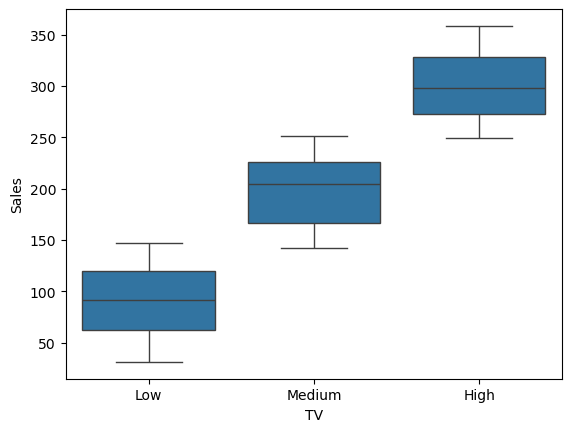

```python
# Created boxplot with TV and Sales
sns.boxplot(x = "TV", y = "Sales", data = data);
```

**Observation:**

> - There is considerable variation in `Sales` across the `TV` groups. The significance of these differences can be tested with a one-way ANOVA.

Now, I'll use a boxplot to determine how `Sales` vary based on the `Influencer` size category.

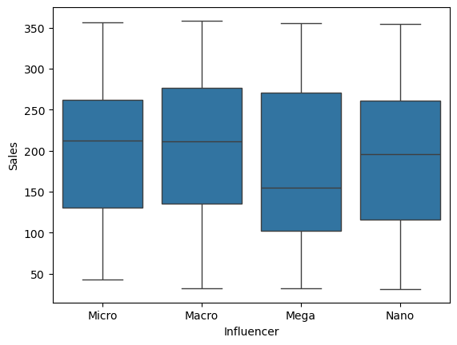

```python
# Created a boxplot with Influencer and Sales.
sns.boxplot(x = "Influencer", y = "Sales", data = data);
```

**Observation:**

> - There is some variation in `Sales` across the `Influencer` groups, but it may not be significant.

### Removing missing data

```python
# I'll drop rows that contain missing data and update the DataFrame.
data = data.dropna(axis=0)

# I'll then confirm the data contains no missing values.
data.isnull().sum(axis=0)
```

```
TV              0
Radio           0
Social Media    0
Influencer      0
Sales           0
dtype: int64
```

## Step 3: Model building

> - I'll fit a linear regression model that predicts `Sales` using one of the independent categorical variables in `data`.

```python
# I'll define the OLS formula.
ols_formula = 'Sales ~ C(TV)'

# I'll create an OLS model.
OLS = ols(formula = ols_formula, data = data)

# I'll fit the model.
model = OLS.fit()

# I'll save the results summary.
model_results = model.summary()

# I'll then display the model results.
model_results
```

OLS Regression Results

| Dep. Variable: | Sales | R-squared: | 0.874 |
| --- | --- | --- | --- |
| Model: | OLS | Adj. R-squared: | 0.874 |
| Method: | Least Squares | F-statistic: | 1971. |
| Date: | Mon, 10 Feb 2025 | Prob (F-statistic): | 8.81e-256 |
| Time: | 11:31:16 | Log-Likelihood: | -2778.9 |
| No. Observations: | 569 | AIC: | 5564. |
| Df Residuals: | 566 | BIC: | 5577. |
| Df Model: | 2 |  |  |
| Covariance Type: | nonrobust |  |  |

|  | coef | std err | t | P>\|t\| | [0.025 | 0.975] |
| --- | --- | --- | --- | --- | --- | --- |
| Intercept | 300.5296 | 2.417 | 124.360 | 0.000 | 295.783 | 305.276 |
| C(TV)[T.Low] | -208.8133 | 3.329 | -62.720 | 0.000 | -215.353 | -202.274 |
| C(TV)[T.Medium] | -101.5061 | 3.325 | -30.526 | 0.000 | -108.038 | -94.975 |

| Omnibus: | 450.714 | Durbin-Watson: | 2.002 |
| --- | --- | --- | --- |
| Prob(Omnibus): | 0.000 | Jarque-Bera (JB): | 35.763 |
| Skew: | -0.044 | Prob(JB): | 1.71e-08 |
| Kurtosis: | 1.775 | Cond. No. | 3.86 |

Notes:  
[1] Standard Errors assume that the covariance matrix of the errors is correctly specified.

### Considerations

> - `TV` was selected as the preceding analysis showed a strong relationship between the `TV` promotion budget and the average Sales.
> - `Influencer` was not selected because it did not show a strong relationship to `Sales` in the analysis.

### Checking model assumptions

> - Now, I'll check that the four linear regression assumptions are upheld for my model.
> - Because this model does not have any continuous independent variables, the **linearity assumption** is not required.
> - As each marketing promotion (row) is independent from one another, the **independence assumption** is not violated.
> - Next, I'll verify that the **normality assumption** is upheld for the model.

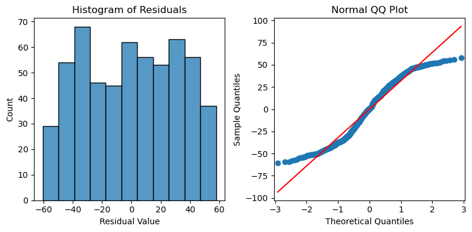

```python
# I'll calculate the residuals.
residuals = model.resid

# Created a 1x2 plot figure.
fig, axes = plt.subplots(1, 2, figsize = (8,4))

# Created a histogram with the residuals.
sns.histplot(residuals, ax=axes[0])

# I set the x label of the residual plot.
axes[0].set_xlabel("Residual Value")

# I set the title of the residual plot.
axes[0].set_title("Histogram of Residuals")

# Created a QQ plot of the residuals.
sm.qqplot(residuals, line='s',ax = axes[1])

# I set the title of the QQ plot.
axes[1].set_title("Normal QQ Plot")

# Used matplotlib's tight_layout() function to add space between plots for a cleaner appearance.
plt.tight_layout()

# I'll then show the plot.
plt.show()
```

**Observations:**

> - There is reasonable concern that the **normality assumption** is not met when `TV` is used as the independent variable predicting `Sales`. The normal q-q forms an 'S' that deviates off the red diagonal line, which is not desired behavior.
> - However, for the purpose of this example, I continue assuming the **normality assumption** is met.

Now, I'll verify the constant variance **(homoscedasticity)** assumption is met for this model.

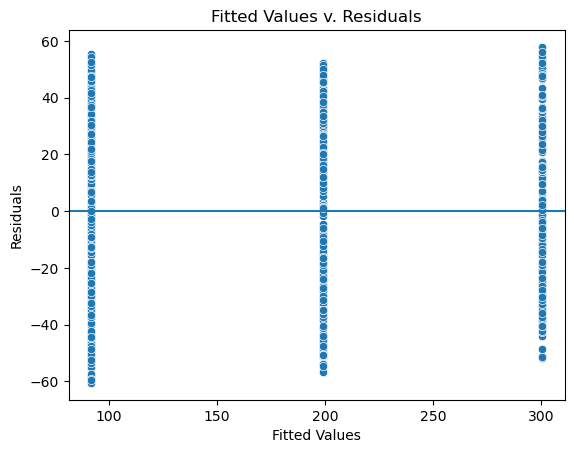

```python
# Created a scatter plot with the fitted values from the model and the residuals.
fig = sns.scatterplot(x = model.fittedvalues, y = model.resid)

# I set the x axis label
fig.set_xlabel("Fitted Values")

# I set the y axis label
fig.set_ylabel("Residuals")

# I set the title
fig.set_title("Fitted Values v. Residuals")

# Added a line at y = 0 to visualize the variance of residuals above and below 0.
fig.axhline(0)

# Finally, I'll display the plot
plt.show()
```

> - The variance where there are fitted values is similarly distributed, validating that the **constant variance** assumption is met.

## Step 4: Results and evaluation

> - In this step, I'll first display the OLS regression results.

```python
# Displayed the model results summary.
model_results
```

OLS Regression Results

| Dep. Variable: | Sales | R-squared: | 0.874 |
| --- | --- | --- | --- |
| Model: | OLS | Adj. R-squared: | 0.874 |
| Method: | Least Squares | F-statistic: | 1971. |
| Date: | Mon, 10 Feb 2025 | Prob (F-statistic): | 8.81e-256 |
| Time: | 11:31:16 | Log-Likelihood: | -2778.9 |
| No. Observations: | 569 | AIC: | 5564. |
| Df Residuals: | 566 | BIC: | 5577. |
| Df Model: | 2 |  |  |
| Covariance Type: | nonrobust |  |  |

|  | coef | std err | t | P>\|t\| | [0.025 | 0.975] |
| --- | --- | --- | --- | --- | --- | --- |
| Intercept | 300.5296 | 2.417 | 124.360 | 0.000 | 295.783 | 305.276 |
| C(TV)[T.Low] | -208.8133 | 3.329 | -62.720 | 0.000 | -215.353 | -202.274 |
| C(TV)[T.Medium] | -101.5061 | 3.325 | -30.526 | 0.000 | -108.038 | -94.975 |

| Omnibus: | 450.714 | Durbin-Watson: | 2.002 |
| --- | --- | --- | --- |
| Prob(Omnibus): | 0.000 | Jarque-Bera (JB): | 35.763 |
| Skew: | -0.044 | Prob(JB): | 1.71e-08 |
| Kurtosis: | 1.775 | Cond. No. | 3.86 |

Notes:  
[1] Standard Errors assume that the covariance matrix of the errors is correctly specified.

**Observations:**

> - Using `TV` as the independent variable results in a linear regression model where $𝑅^{2} = 0.874$. This model explains $87.4\%$ of the variation in `Sales`. This makes the model an effective predictor of `Sales`.
> - The default `TV` category for the model is `High`, because there are coefficients for the other two `TV` categories, `Medium` and `Low`. According to the model, `Sales` with a `Medium` or `Low` `TV` category are lower on average than `Sales` with a `High` `TV` category. For example, the model predicts that a `Low` `TV` promotion would be 208.813 (in millions of dollars) lower in `Sales` on average than a `High` `TV` promotion.
> - The p-value for all coefficients is $0.000$, meaning all coefficients are statistically significant at $p=0.05$. The 95% confidence intervals for each coefficient would be reported when presenting my results to stakeholders. For example, there is a $95\%$ chance the interval $[-215.353,-202.274]$ contains the true parameter of the slope of $\beta_{TVLow}$, which is the estimated difference in promotion sales when a `Low` `TV` promotion is chosen instead of a `High` `TV` promotion.

### Performing a one-way ANOVA test

> - With the model fit, I'll run a one-way ANOVA test to determine whether there is a statistically significant difference in `Sales` among groups.

```python
# Here I created a one-way ANOVA table for the fit model.
sm.stats.anova_lm(model, typ=2)
```

|  | sum_sq | df | F | PR(>F) |
| --- | --- | --- | --- | --- |
| C(TV) | 4.052692e+06 | 2.0 | 1971.455737 | 8.805550e-256 |
| Residual | 5.817589e+05 | 566.0 | NaN | NaN |

**Observations from the ANOVA test:**

> - **The null hypothesis:** there is no difference in `Sales` based on the `TV` promotion budget.
> - **The alternative hypothesis:** there is a difference in `Sales` based on the `TV` promotion budget.

**Conclusions from the one-way ANOVA test:**

> - The F-test statistic is 1971.46 and the p-value is $8.81 * 10^{-256}$ (i.e., very small). Because the p-value is less than 0.05, I must reject the null hypothesis that there is no difference in `Sales` based on the `TV` promotion budget.
> - The results of the one-way ANOVA test indicate that I can reject the null hypothesis in favor of the alternative hypothesis. There is a statistically significant difference in `Sales` among `TV` groups.

### Performing an ANOVA post hoc test

> - Due to finding significant results from the one-way ANOVA test, I can apply the ANOVA post hoc tests such as the Tukey’s HSD post hoc test.

```python
# I'll perform the Tukey's HSD post hoc test.
tukey_oneway = pairwise_tukeyhsd(endog = data["Sales"], groups = data["TV"])

# I'll display the results
tukey_oneway.summary()
```

Multiple Comparison of Means - Tukey HSD, FWER=0.05

| group1 | group2 | meandiff | p-adj | lower | upper | reject |
| --- | --- | --- | --- | --- | --- | --- |
| High | Low | -208.8133 | 0.0 | -216.6367 | -200.9898 | True |
| High | Medium | -101.5061 | 0.0 | -109.3202 | -93.6921 | True |
| Low | Medium | 107.3072 | 0.0 | 99.7066 | 114.9077 | True |

**Observation:**

> - All three rows indicate that I can reject the null hypotheses that there is no significant difference between the `Sales` of these groups.

# Conclusion:

> - I conducted a post hoc test to determine which `TV` groups are different and how many are different from each other. This provides more detail than the one-way ANOVA results, which can at most determine that at least one group is different. Further, using the Tukey HSD controls for the increasing probability of incorrectly rejecting a null hypothesis from peforming multiple tests.
> - The results were that `Sales` are not the same between any pair of `TV` groups within this dataset.

# Stakeholder Summary:

- High TV promotion budgets result in significantly more sales than both medium and low TV promotion budgets. Medium TV promotion budgets result in significantly more sales than low TV promotion budgets.
- Specifically, following are estimates for the difference between the mean sales resulting from different pairs of TV promotions, as determined by the Tukey's HSD test:
> - Estimated difference between the mean sales resulting from High and Low TV promotions: \$208.81 million (with 95% confidence that the exact value for this difference is between 200.99 and 216.64 million dollars).
> - Estimated difference between the mean sales resulting from High and Medium TV promotions: \$101.51 million (with 95% confidence that the exact value for this difference is between 93.69 and 109.32 million dollars).
> - difference between the mean sales resulting from Medium and Low TV promotions: \$107.31 million (with 95% confidence that the exact value for this difference is between 99.71 and 114.91 million dollars).
- The linear regression model estimating `Sales` from `TV` had an R-squared value of $0.874, making it a fairly accurate estimator. The model showed a statistically significant relationship between the `TV` promotion budget and `Sales`.
- The results of the one-way ANOVA test indicate that the null hypothesis that there is no difference in Sales based on the TV promotion budget can be rejected. Through the ANOVA post hoc test, a significant difference between all pairs of TV promotions was found.
- The difference in the distribution of sales across TV promotions was determined significant by both a one-way ANOVA test and a Tukey’s HSD test.